# Homework 2: The Big Short

**This homework is due Friday February 26, 2016 at 5:00 PM. When complete, submit your code in the R Markdown file and the knitted HTML via GitHub.**

# Background

This homework is motivated by circumstances surrounding the [financial crisis of 2007-2008](https://en.wikipedia.org/wiki/Financial_crisis_of_2007%E2%80%9308). We titled the homework *The Big Short*, after the book on the same topic that was also recently made into a movie.

Part of what caused the financial crisis was that the risk of certain securities sold by financial institutions were underestimated. Specifically, the risk of mortgage-backed securities (MBS) and collateralized debt obligations (CDO), the price of which depends on homeowners making their monthly payments, was grossly underestimated. A combination of factors resulted in many more defaults than were expected. This resulted in a crash of the prices of these securities. As a consequence, banks lost so much money that they needed bailouts to avoid default.

Here we present a **very** simplified version of what happened with some of these securities. Hopefully it will help you understand how a wrong assumption about the statistical behavior of events can lead to substantial differences between what the model predicts and what actually happens. Specifically, we will see how using an independence assumption can result in misleading conclusions. Before we start with the specific application we ask you about a simple casino game.

# Problem 1

In the game of [roullete](https://en.wikipedia.org/wiki/Roulette) you can bet on several things including black or red. On this bet, if you win, you double your earnings. How does the casino make money on this then? If you look at the [possibilities](http://www.math.uah.edu/stat/games/Roulette.png) you realize that the chance of red or black are both slightly less than 1/2. There are two green spots, so the of landing on black (or red) is actually 18/38, or 9/19.

## Problem 1A

Let’s make a quick sampling model for this simple version of roulette. You are going to bet a dollar each time you play and always bet on black. Make a box model for this process using the `sample` function. Write a function `get_outcome` that takes as an argument the number of times you play $N$ and returns your earnings $S_N$.

```r
##Your code here

get_outcome <-function(N){
  # Make a roulette
  roulette <- rep(c("black","red","green"),38*c(18/38,18/38,2/38))
  draw <- sample(roulette, N, replace=TRUE)
  S_N <- sum(as.numeric(draw=="black"))*1 + sum(as.numeric(draw !="black"))*(-1)
  names(S_N) <- "This is your earning:"
  return(S_N)
}
```

## Problem 1B

Use Monte Carlo simulation to study the distribution of total earnings $S_N$ for $N=10,25,100,1000$. That is, study the distribution of earnings for different number of plays. What are the distributions of these two random variables? How do the expected values and standard errors change with $N$? Then do the same thing for the average winnings $S_N/N$. What result that you learned in class predicts this?

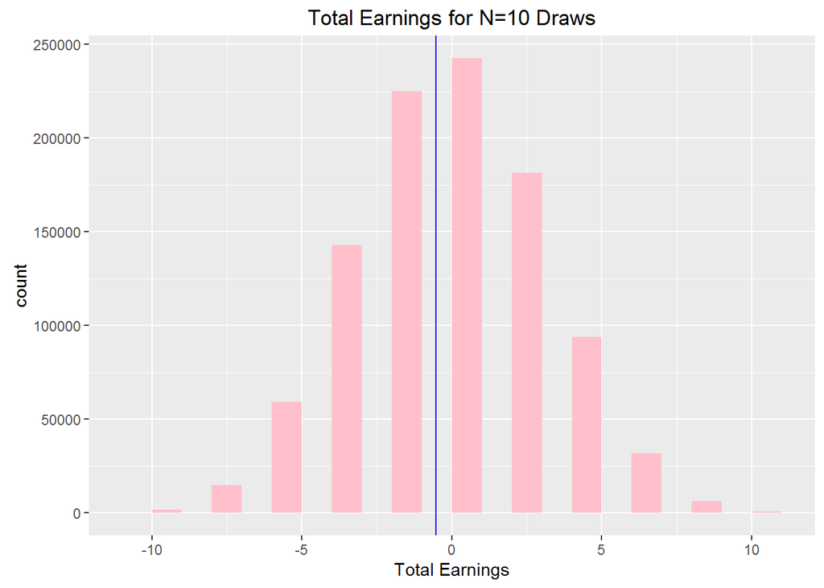

```r
##Your code here

# set seed
set.seed(02138)
# initialize number of simulations
nIter <-1000000
# initialize place-holder for total earnigns
S_N1 <-rep(NA,nIter)
S_N2 <-rep(NA,nIter)
S_N3 <-rep(NA,nIter)
S_N4 <-rep(NA,nIter)

for (i in 1:nIter){
  S_N1[i] <- get_outcome(10)
  S_N2[i] <- get_outcome(25)
  S_N3[i] <- get_outcome(100)
  S_N4[i] <- get_outcome(1000)
}
S_N <-data.frame(S_N1,S_N2,S_N3,S_N4)

## Look at distribution of Total Earnings with different N

# EDA: Histogram
library(ggplot2)
ggplot(S_N,aes(S_N1))+geom_histogram(binwidth=1,fill="pink") +xlab("Total Earnings") + ggtitle("Total Earnings for N=10 Draws") +geom_vline(xintercept=mean(S_N$S_N1),col="blue")
```

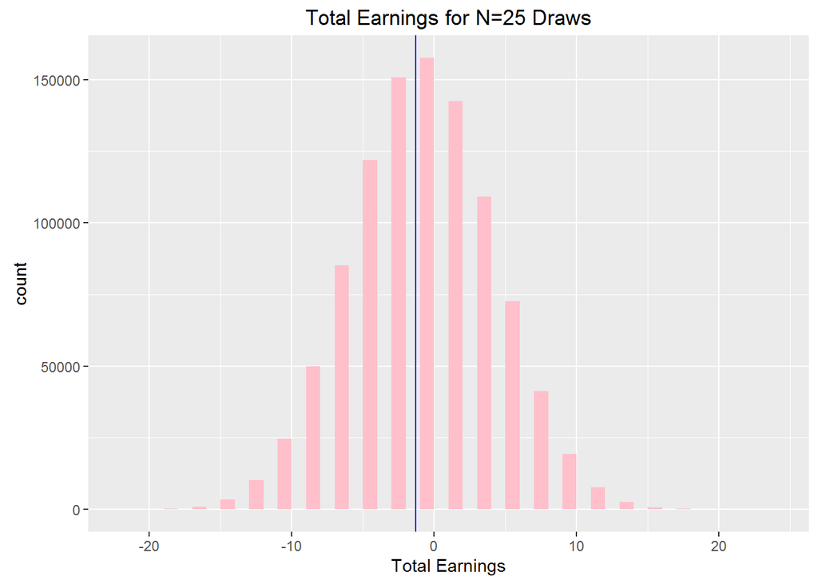

```r
ggplot(S_N,aes(S_N2))+geom_histogram(binwidth=1,fill="pink") +xlab("Total Earnings") + ggtitle("Total Earnings for N=25 Draws") +geom_vline(xintercept=mean(S_N$S_N2),col="blue")
```

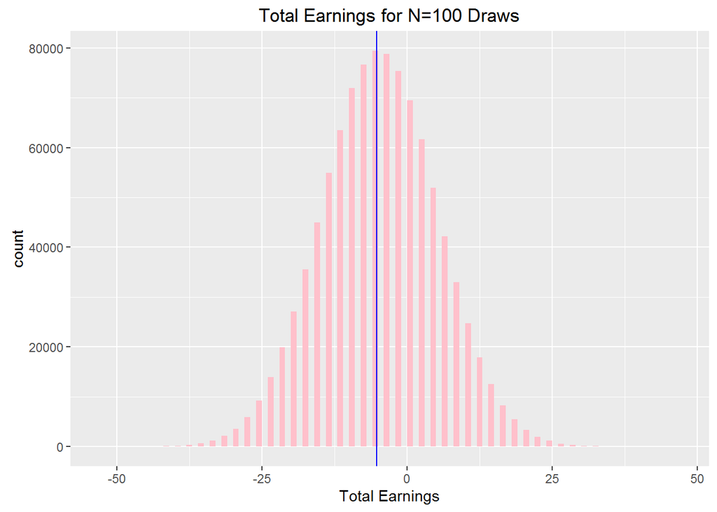

```r
ggplot(S_N,aes(S_N3))+geom_histogram(binwidth=1,fill="pink") +xlab("Total Earnings") + ggtitle("Total Earnings for N=100 Draws") +geom_vline(xintercept=mean(S_N$S_N3),col="blue")
```

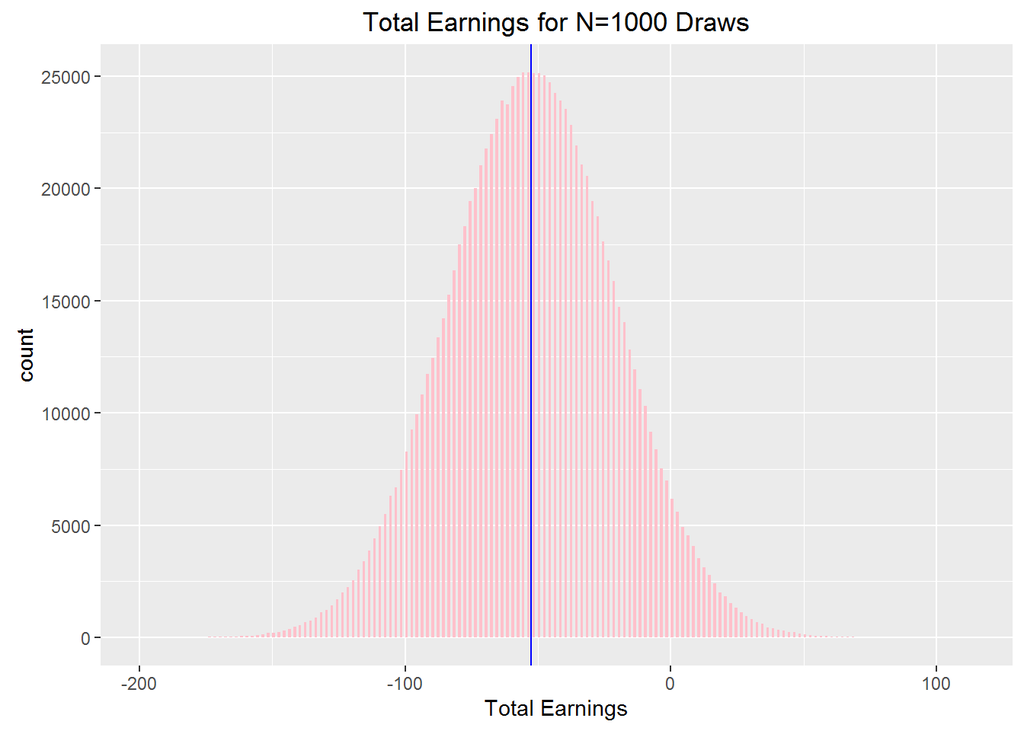

```r
ggplot(S_N,aes(S_N4))+geom_histogram(binwidth=1,fill="pink") +xlab("Total Earnings") + ggtitle("Total Earnings for N=1000 Draws") +geom_vline(xintercept=mean(S_N$S_N4),col="blue")
```

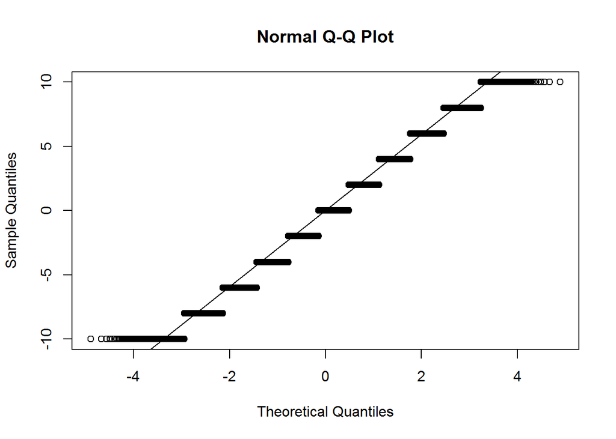

```r
# EDA: QQ-plot to check normality
qqnorm(S_N$S_N1)
qqline(S_N$S_N1)
```

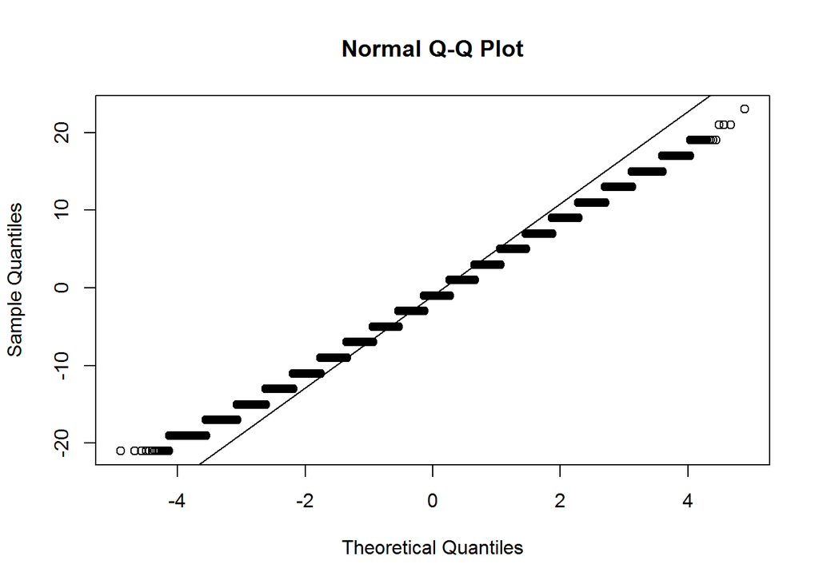

```r
qqnorm(S_N$S_N2)
qqline(S_N$S_N2)
```

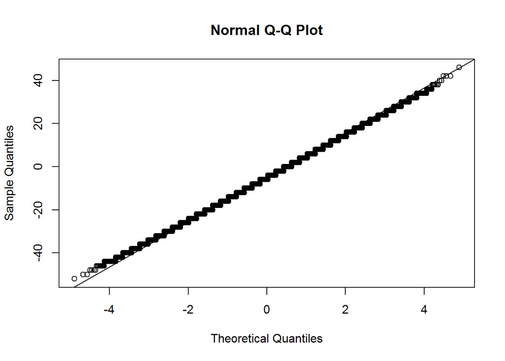

```r
qqnorm(S_N$S_N3)
qqline(S_N$S_N3)
```

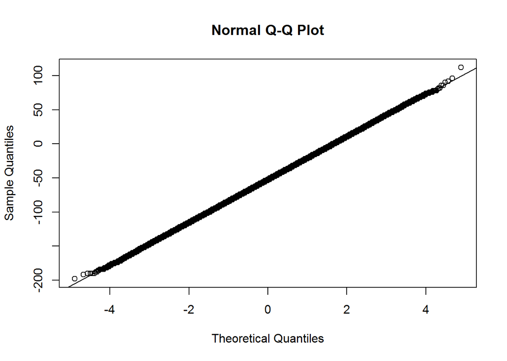

```r
qqnorm(S_N$S_N4)
qqline(S_N$S_N4)
```

```r
# expected values
sapply(S_N, mean)
```

```
##       S_N1       S_N2       S_N3       S_N4
##  -0.526588  -1.310288  -5.264076 -52.686478
```

```r
#  standard errors
sapply(S_N,sd)
```

```
##      S_N1      S_N2      S_N3      S_N4
##  3.157977  4.990458  9.982559 31.586825
```

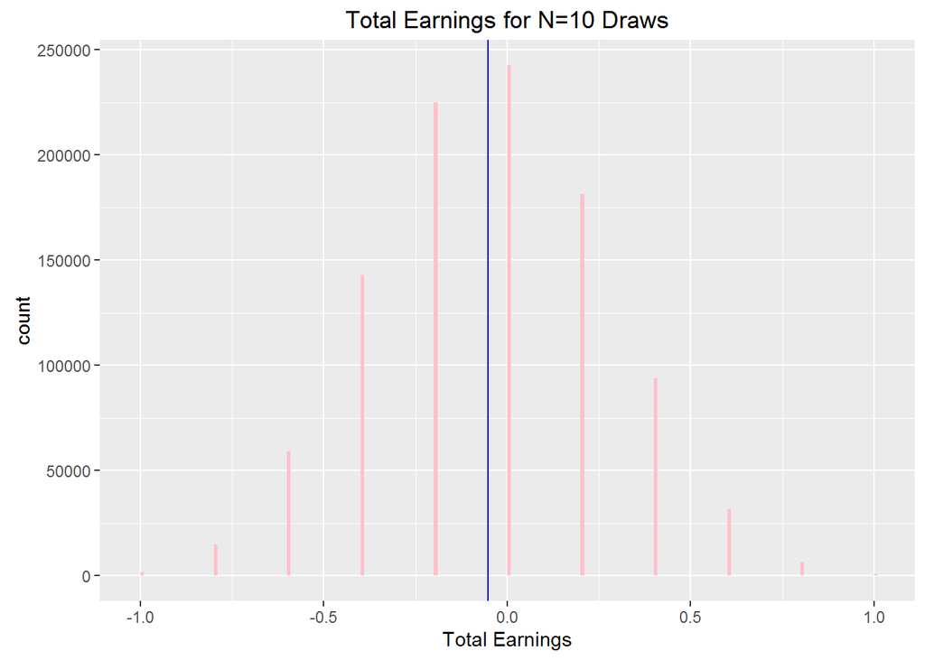

```r
## Look at distribution of average Earnings with different N
S_N$S_N1 <- S_N$S_N1/10
S_N$S_N2 <- S_N$S_N2/25
S_N$S_N3 <- S_N$S_N3/100
S_N$S_N4 <- S_N$S_N4/1000

# EDA: Histogram
ggplot(S_N,aes(S_N1))+geom_histogram(binwidth=0.01,fill="pink") +xlab("Total Earnings") + ggtitle("Total Earnings for N=10 Draws") +geom_vline(xintercept=mean(S_N$S_N1),col="blue")
```

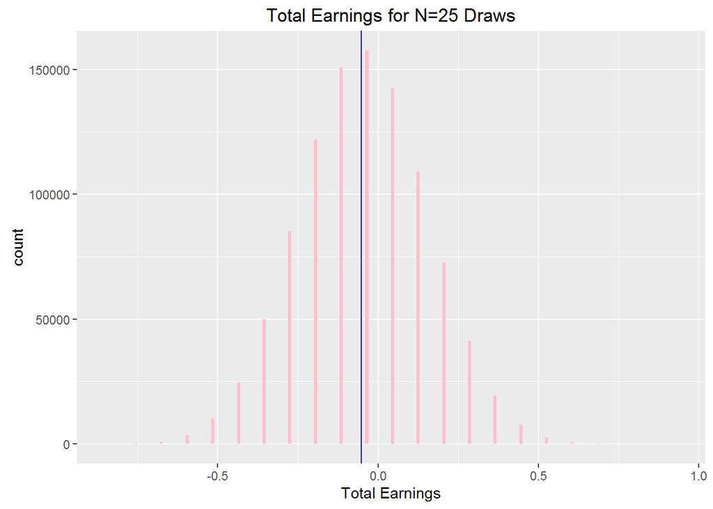

```r
ggplot(S_N,aes(S_N2))+geom_histogram(binwidth=0.01,fill="pink") +xlab("Total Earnings") + ggtitle("Total Earnings for N=25 Draws") +geom_vline(xintercept=mean(S_N$S_N2),col="blue")
```

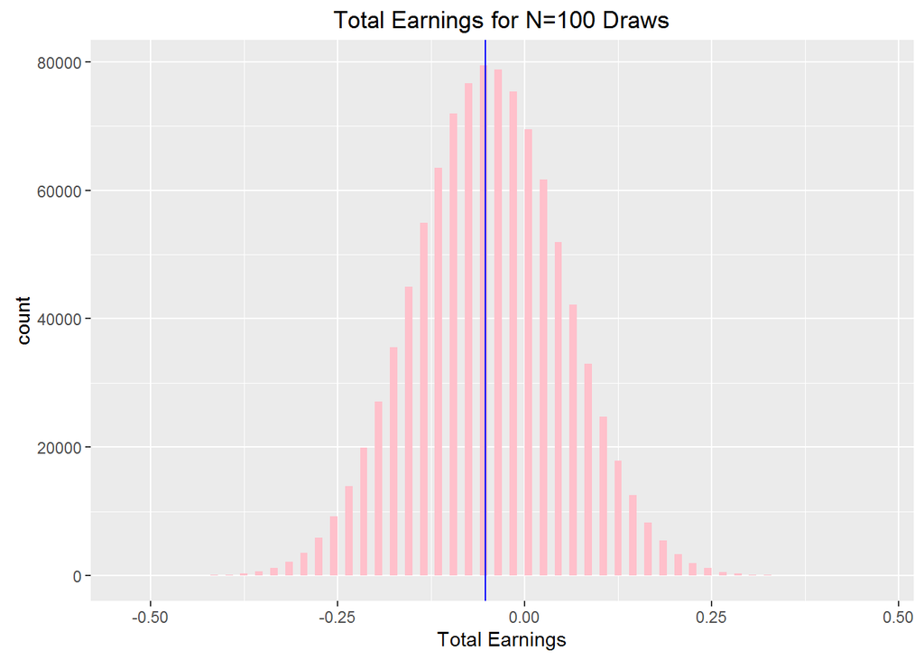

```r
ggplot(S_N,aes(S_N3))+geom_histogram(binwidth=0.01,fill="pink") +xlab("Total Earnings") + ggtitle("Total Earnings for N=100 Draws") +geom_vline(xintercept=mean(S_N$S_N3),col="blue")
```

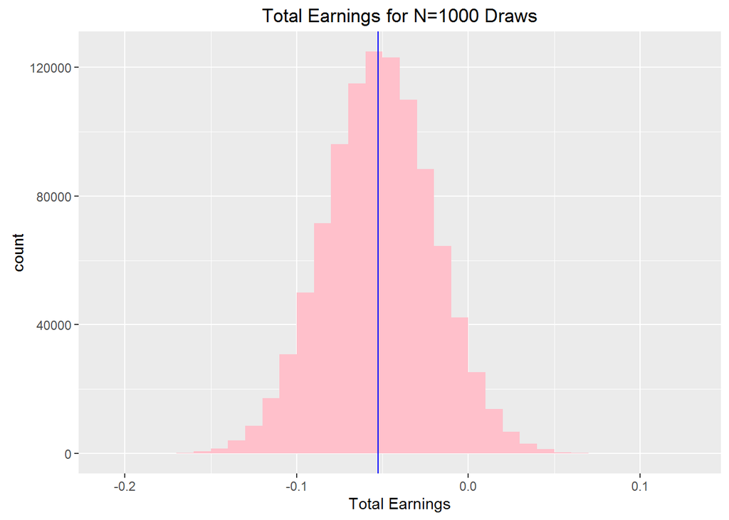

```r
ggplot(S_N,aes(S_N4))+geom_histogram(binwidth=0.01,fill="pink") +xlab("Total Earnings") + ggtitle("Total Earnings for N=1000 Draws") +geom_vline(xintercept=mean(S_N$S_N4),col="blue")
```

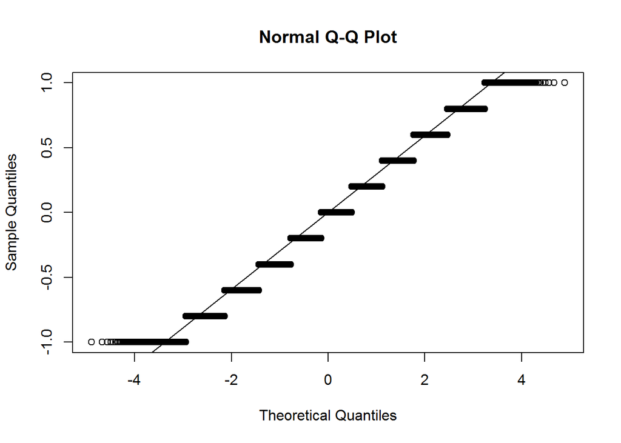

```r
# EDA: QQ-plot
qqnorm(S_N$S_N1)
qqline(S_N$S_N1)
```

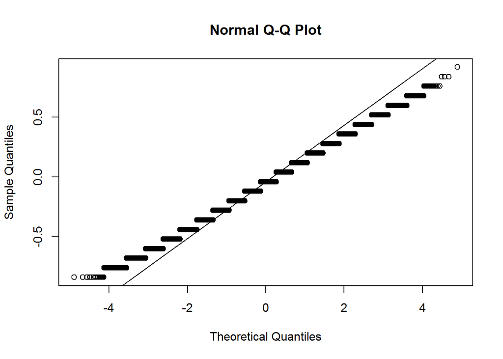

```r
qqnorm(S_N$S_N2)
qqline(S_N$S_N2)
```

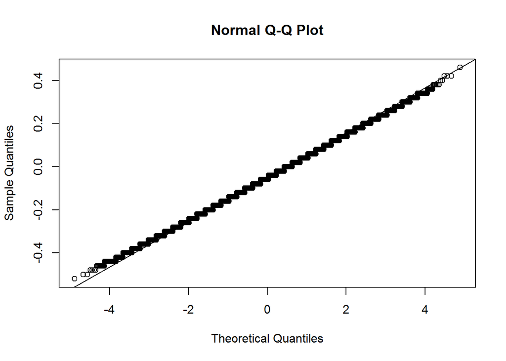

```r
qqnorm(S_N$S_N3)
qqline(S_N$S_N3)
```

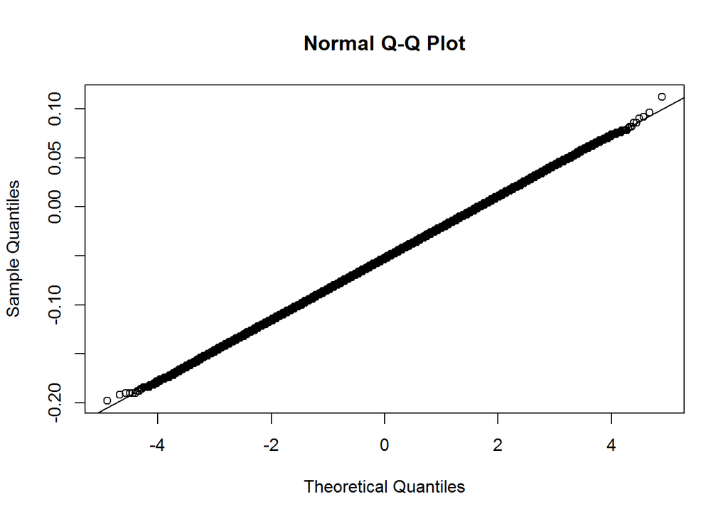

```r
qqnorm(S_N$S_N4)
qqline(S_N$S_N4)
```

```r
# expected values
sapply(S_N, mean)
```

```
##        S_N1        S_N2        S_N3        S_N4
## -0.05265880 -0.05241152 -0.05264076 -0.05268648
```

```r
# standard errors
sapply(S_N,sd)
```

```
##       S_N1       S_N2       S_N3       S_N4
## 0.31579771 0.19961830 0.09982559 0.03158683
```

## Problem 1C

What is the expected value of our sampling model? What is the standard deviation of our sampling model?

Your answer here.

**Our sampling model** is to bet “black” from a random draw of Roulette which has 18 “black” spots, 18 “red” spots, and 2 “green” spots. It follows a *Bernoulli Distribution* with probability $p=\frac{18}{38}$. So, the expected value of our sampling model is $E=\frac{18}{38}=0.4736842$ . The standard deviation of our sampling model is $SD=\sqrt(\frac{18}{38} (1-\frac{18}{38}))=0.499307$ .

## Problem 1D

Use CLT to approximate the probability that the casino loses money when you play 25 times. Then use a Monte Carlo simulation to confirm.

Your answer here.

The probability that the casino loses money is equal to the probability that your total earnings >0 when you play 25 times, and also is equivalent to the probability that your average earnings >0 when you play 25 times. However, we don’t know the distribution of average earnings when you play 25 times. We know that, for each play, your expected earning is $E=(1)(\frac{18}{38})+(-1)(\frac{20}{38})=-\frac{2}{38}= -0.05263158$ and standard deviation is $SD=\sqrt((1-(-\frac{2}{38}))^2\frac{18}{38}+(-1-(-\frac{2}{38}))^2\frac{20}{38}))=0.998614$

By Central Limit Theorem, we could appximate the distribution of average earnings when you play 25 times.The Central Limit Theorem tells us that, if we randomly draw from our sampling model sufficiently large number of times, the average number of casino loses money is approximately normally distributed.

So, if we repeat the play 25 times, the average earnings follows a Normal distribution with the expected value: $E=(1)(\frac{18}{38})+(-1)(\frac{20}{38})=-\frac{2}{38}= -0.05263158$  
And the standard deviation: $SD=\frac{\sqrt((1-(-\frac{2}{38}))^2(\frac{18}{38})+(-1-(-\frac{2}{38}))^2(\frac{20}{38})))}{\sqrt{25}}=0.1997228$

Thus, if we integrate the normal probability density function for values >0, we get the probability that the casino loses money when you play 25 times, or your earnings is positive when you play 25 times:

```r
##Your code here

## Use CLT to approximate the probability that the casino loses money when you play 25 times.
integrate(dnorm,lower=0,upper=100,mean=-0.05263158,sd=0.1997228)
```

```
## 0.3960737 with absolute error < 7.5e-06
```

```r
## Then use a Monte Carlo simulation to confirm the probability of casino loses money when you play 25 times.
set.seed(02138)
# initialize number of simulations
nIter <-1000000
# initialize place-holder for indicators of losing money
lose_money <-rep(NA,nIter)
for(i in 1:nIter){
  # if your total earnings >0 when you play 25 times, then casino loses money
 lose_money[i] <- as.numeric(get_outcome(25)>0)
}
# probability of losing money would be:
mean(lose_money)
```

```
## [1] 0.39596
```

Results from CLT appriximation and Monte Carlo Simulation is very close.

## Problem 1E

In general, what is the probability that the casino loses money as a function of $N$? Make a plot for values ranging from 25 to 1,000. Why does the casino give you free drinks if you keep playing?

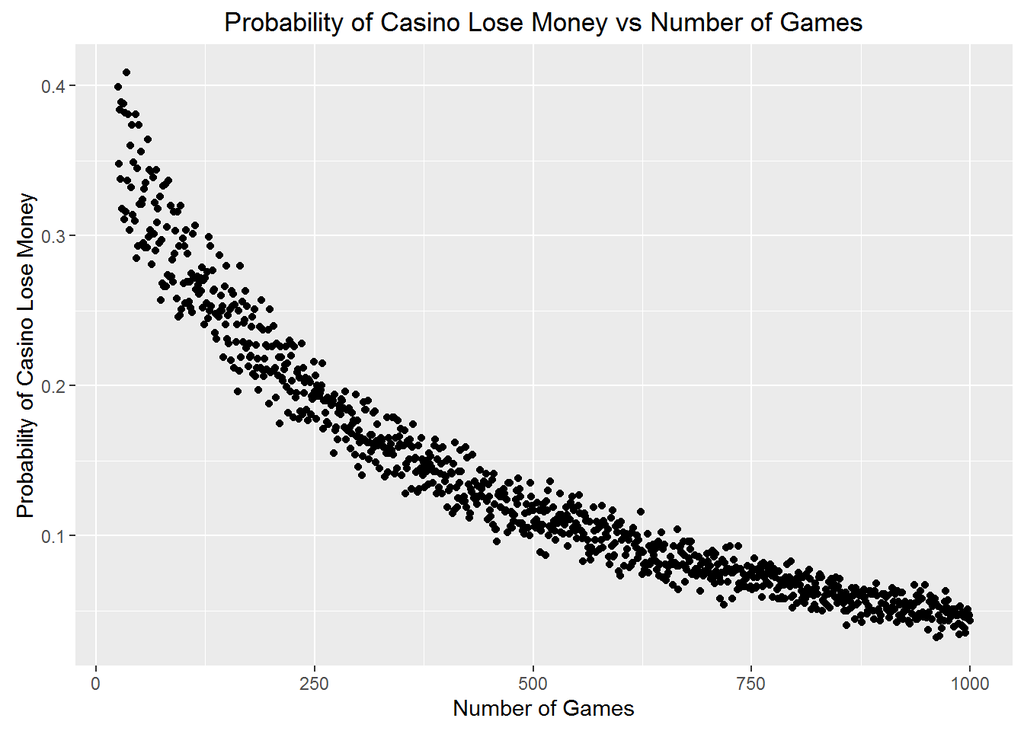

```r
##Your code here

## use a Monte Carlo simulation
set.seed(02138)

# initialize number of simulations
nIter <-1000

# initialize place-holder for probability
p <-rep(NA,1000)

for(n in 25:1000){
  lose_money <-rep(NA,nIter)
  for(i in 1:nIter){
    lose_money[i] <- as.numeric(get_outcome(n)>0)
  }
  # probability of casino lose money
  p[n]<-mean(lose_money)
}

# plot
library(dplyr)
library(ggplot2)
dat <-data.frame(n=seq(1:1000),p)

filter(dat,n>=25)%>% ggplot(aes(x=n,y=p))+geom_point()+xlab("Number of Games")+ylab("Probability of Casino Lose Money")+ggtitle("Probability of Casino Lose Money vs Number of Games")
```

Your answer here.

Same as argument in 1D, in general,if we repeat the play N times, the average earnings follows a Normal distribution with the expected value: $E=(1)(\frac{18}{38})+(-1)(\frac{20}{38})=-\frac{2}{38}= -0.05263158$  
And the standard deviation: $SD=\frac{\sqrt((1-(-\frac{2}{38}))^2(\frac{18}{38})+(-1-(-\frac{2}{38}))^2(\frac{20}{38})))}{\sqrt{N}}$

Thus, if we integrate the normal probability density function for values >0, we get the probability that the casino loses money when you play N times, or your earnings is positive when you play N times. Notice that, when N gets larger and larger, the distribution is more and more concentrated around the mean -0.05263158, so the probability of positive earnings will get smaller and smaller. Casino give you free drinks if you keep playing, because it will keep profit from you if you stay there.

# Problem 2

You run a bank that has a history of identifying potential homeowners that can be trusted to make payments. In fact, historically, in a given year, only 2% of your customers default. You want to use stochastic models to get an idea of what interest rates you should charge to guarantee a profit this upcoming year.

## Problem 2A

Your bank gives out 1,000 loans this year. Create a sampling model and use the function `sample` to simulate the number of foreclosure in a year with the information that 2% of customers default. Also suppose your bank loses $120,000 on each foreclosure. Run the simulation for one year and report your loss.

Your answer here.

The sampling model is, randomly draw 1000 times independently from a Bernoulli Distribution with probability 0.02 default, if default, the bank lose $120,000;otherwise the bank lose $0.

```r
##your code here

# set seed
set.seed(02138)
# sample loss for one year
sum(sample(c(0,120000),size=1000,replace=TRUE,prob=c(0.98,0.02)))
```

```
## [1] 1560000
```

## Problem 2B

Note that the loss you will incur is a random variable. Use Monte Carlo simulation to estimate the distribution of this random variable. Use summaries and visualization to describe your potential losses to your board of trustees.

```r
##your code here

# set seed
set.seed(02138)
# replicate the process for 1,000,000 times
MCloss <-replicate(1000000 ,sum(sample(c(0,120000),size=1000,replace=TRUE,prob=c(0.98,0.02))))

# summarise
library(dplyr)
data.frame(MCloss)%>%summarise(ave_loss=mean(MCloss),
                sd_loss=sd(MCloss),
                min_loss=min(MCloss),
                max_loss=max(MCloss),
                total=n())
```

```
##   ave_loss  sd_loss min_loss max_loss   total
## 1  2398984 531600.3   120000  5520000 1000000
```

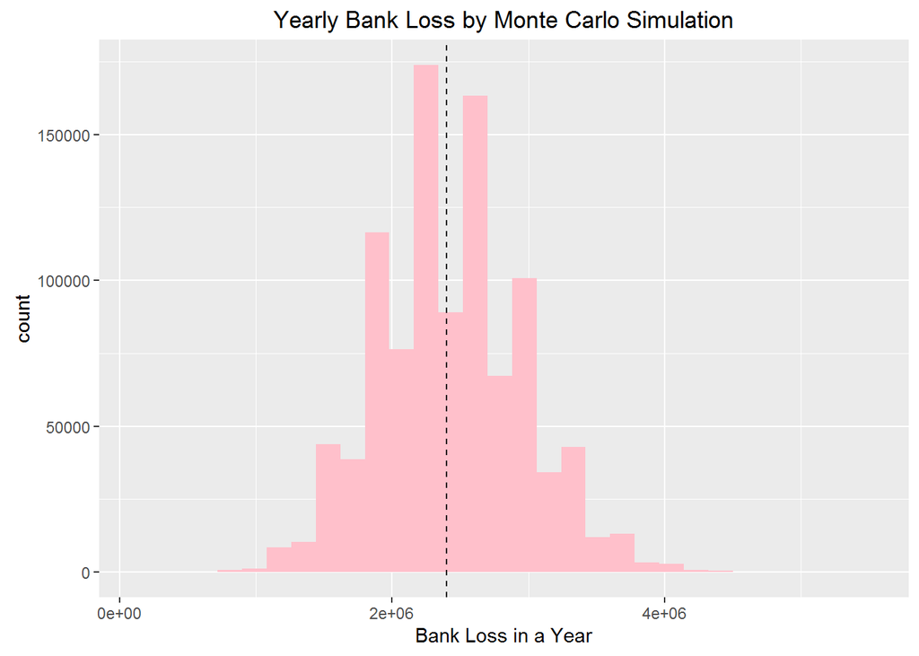

```r
# visulization
library(ggplot2)
data.frame(MCloss) %>%ggplot(aes(MCloss))+geom_histogram(fill="pink") +xlim(120000,5520000)+xlab("Bank Loss in a Year") + ggtitle("Yearly Bank Loss by Monte Carlo Simulation") +geom_vline(xintercept=mean(MCloss),col="black",linetype="dashed")
```

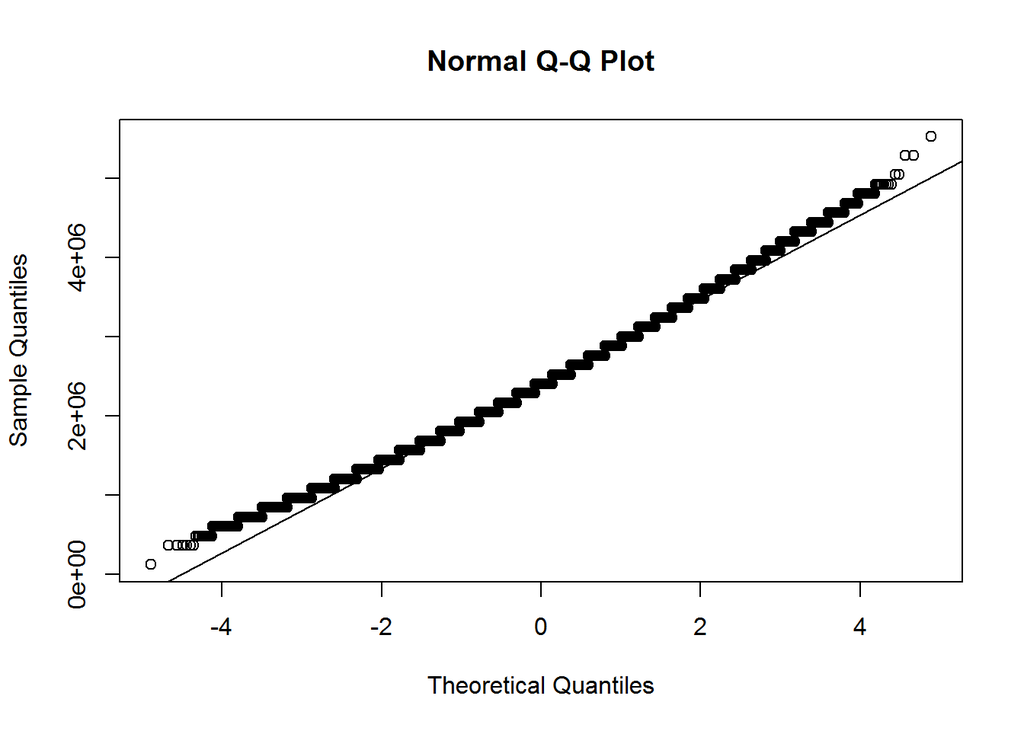

```r
qqnorm(MCloss)
qqline(MCloss)
```

Your answer here.

## Problem 2C

The 1,000 loans you gave out were for $180,000. The way your bank can give out loans and not lose money is by charging an interest rate. If you charge an interest rate of, say, 2% you would earn $3,600 for each loan that doesn’t foreclose. At what percentage should you set the interest rate so that your expected profit totals $100,000. Hint: Create a sampling model with expected value 100 so that when multiplied by the 1,000 loans you get an expectation of $100,000. Corroborate your answer with a Monte Carlo simulation.

Your solution here.

**Sampling Model:** For each loan, the profit is a random variable taking 2 values as outcome. If default, profit=-120000, with probability=0.02; if not default, $profit=(180000)(rate)$, with probability=0.98. So the expected value of our sampling model is: $E=(-120000)(0.02)+ (180000)(rate)(0.98) = -2400 + 176400(rate)$

If set the expected value to 100, then interest rate should be set to 1.42%.

```r
###your code here

# Corroborate your answer with a Monte Carlo simulation.
loss <- -120000
gain <-180000*(0.0142)
# If set to 1.417%, the expected profit would be:
mean(replicate(nIter,sum(sample(c(gain,loss),size=1000,replace=TRUE,prob=c(0.98,0.02)))))
```

```
## [1] 84045.48
```

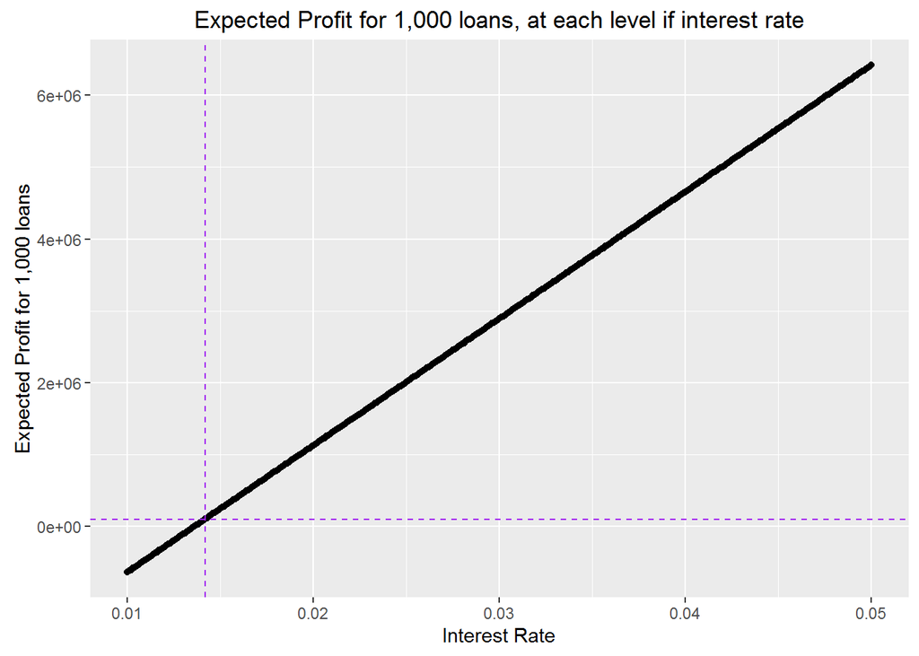

```r
# Look at interest rate & expected proifit relationship
# Monte Carlo Simulation: Assume interest rate between 1% to 5%, simulate 1,000,000 times to get profit for 1000 loans at the set interest rate
set.seed(02138)

# initialize number of simulations
nIter <-100000
# initialize place-holder for expected profit for a sinlg loan
profit <-rep(NA,401)
rate <-seq(from=0.01,to=0.05,by=0.0001)

for(i in 1:401){
    loss <- -120000
    gain <-180000*rate[i]
    profit[i] <-mean(replicate(nIter,sum(sample(c(gain,loss),size=1000,replace=TRUE,prob=c(0.98,0.02)))))
  }

dat <-data.frame(rate,profit)


# plot
library(dplyr)

dat%>% ggplot(aes(x=rate,y=profit))+geom_point()+xlab("Interest Rate")+ylab("Expected Profit for 1,000 loans")+ggtitle("Expected Profit for 1,000 loans, at each level if interest rate") +geom_vline(xintercept=min(dat$rate[dat$profit>=100000]) ,col='purple',linetype="dashed")+geom_hline(yintercept=100000 ,col='purple',linetype="dashed")
```

## Problem 2D

In problem 2C, you were able to set a very low interest rate. Your customers will be very happy and you are expected to earn $100,000 in profits. However, that is just an expectation. Our profit is a random variable. If instead of a profit your bank loses money, your bank defaults. Under the conditions of Problem 2C, what is the probability that your profit is less than 0?

Your answer here.

There are two ways to address this problem: CLT and Monte Carlo Simulation.

- Central Limit Theorem

For each loan, the profit is a random variable taking 2 values as outcome. If default, profit=-120000, with probability=0.02; if not default, $profit=(180000)(rate), with probability=0.98. So the expected profit for 1 loan is: $E=(-120000) (0.02)+ (180000)(rate)(0.98)$. The SD for 1,000 loan is :$SD=\mid (180000)(rate)-(-120000) \mid \sqrt{0.02(1-0.02)}$

By central limit theorem, the average of 1000 independent random variable is approximately normally distributed, with mean $E=(-120000) (0.02)+ (180000)(rate)(0.98)$ and standard deviation $SD=\frac{\mid (180000)(rate)-(-120000) \mid \sqrt{0.02(1-0.02)}}{1000}$ . The probability of bank default for 1,000 loans (sum profit of 1,000 loans <0) is equivalent to the probability of bank default for 1 loan (profit of 1 loan <0), because we assume they are independent here.

Hence, integrate the normal distribution up to 0 gives the probability of bank profit is less than 0:

```r
##your code here

# Solution 1: CLT
ave <- 180000*0.0142*0.98-120000*0.02
std <- abs(180000*0.0142+120000)*sqrt(0.98*0.02)/sqrt(1000)
integrate(dnorm,lower=-1000,upper=0,mean=ave,sd=std)
```

```
## 0.4025047 with absolute error < 4.5e-15
```

```r
# Solution 2: Monte Carlo simulation
# Set interest rate to 1.42%.
rate <- 0.0142
set.seed(02138)

# initialize number of simulations
nIter <-100000

# initialize place-holder for Binary result: your bank lose money=Y/N
profit <-rep(NA,nIter)
# give out 1000 loans/year, simulate nIter times
loss <- -120000
gain <-180000*0.0142
# probability of your bank loses money
mean(replicate(nIter,sum(sample(c(gain,loss),size=1000,replace=TRUE,prob=c(0.98,0.02)))<0))
```

```
## [1] 0.44129
```

CLT gives 0.40, Monte Carlo Simulation gives 0.44. The difference would be the distribution assumption by CLT.

## Problem 2E

Note that the probability of losing money is quite high. To what value would you have to raise interest rates in order to make the probability of losing money, and your bank and your job, as low as 0.001? What is the expected profit with this interest rate? Corroborate your answer with a Monte Carlo simulation.

Hint: Use the following short cut. If $p$ fraction of a box are $a$s and $(1-p)$ are $b$s, then the SD of the list is $\mid a-b \mid \sqrt{p(1-p)}$

Your solution here.

Same as 2D, There are two ways to address this problem: CLT and Monte Carlo Simulation.

- Central Limit Theorem

For each loan, the profit is a random variable taking 2 values as outcome. If default, profit=-120000, with probability=0.02; if not default, $profit=(180000)(rate), with probability=0.98. So the expected profit for 1 loan is: $E=(-120000) (0.02)+ (180000)(rate)(0.98)$. The SD for 1,000 loan is :$SD=\mid (180000)(rate)-(-120000) \mid \sqrt{0.02(1-0.02)}$

By central limit theorem, the average of 1000 independent random variable is approximately normally distributed, with mean $E=(-120000) (0.02)+ (180000)(rate)(0.98)$ and standard deviation $SD=\frac{\mid (180000)(rate)-(-120000) \mid \sqrt{0.02(1-0.02)}}{1000}$ . The probability of bank default for 1,000 loans (sum profit of 1,000 loans <0) is equivalent to the probability of bank default for 1 loan (profit of 1 loan <0), because we assume they are independent here.

Hence, integrate the normal distribution up to 0 gives the probability of bank profit is less than 0, set this number to 0.001 and reverse engineer to get the interest rate.

```r
###your code here

# Solution 1: CLT by Numerically evaluate equation
library(nleqslv)
fun <-function(x){
  ave <- 180000*x*0.98-120000*0.02
  std <- abs(180000*x+120000)*sqrt(0.98*0.02)/sqrt(1000)
  qnorm(0.001, mean=ave, sd=std )
}

better_rate <- nleqslv(0,fun,jacobian=TRUE,control=list(btol=.01))$x
# To what value would you have to raise interest rates in order to make the probability of losing money, and your bank and your job, as low as 0.001?
better_rate
```

```
## [1] 0.02323666
```

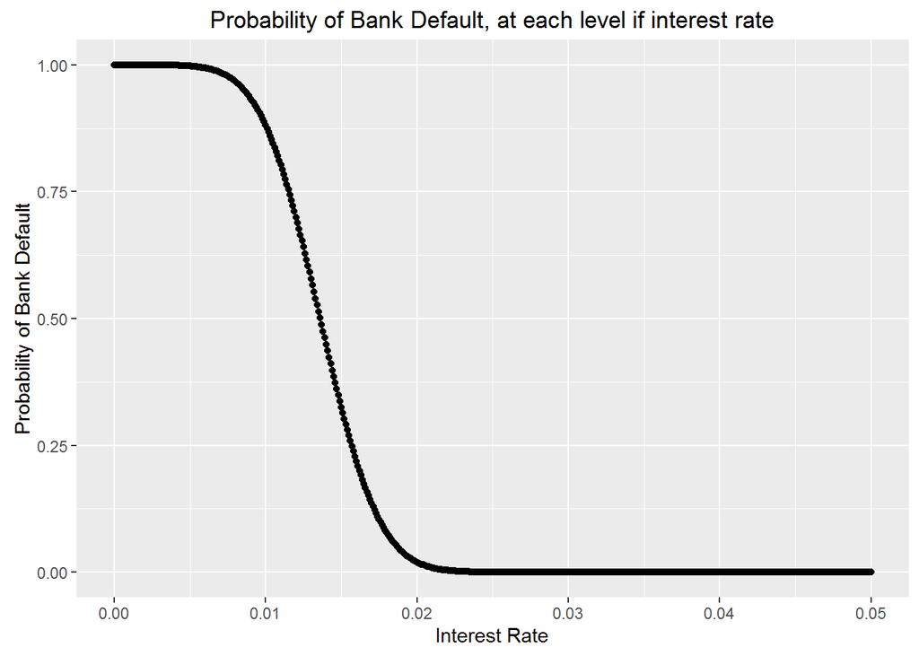

```r
# Evaluate relation between interest rate and probability of bank default, and visualize, by Monte Carlo Simulation
rate <-seq(from=0,to=0.05,by=0.0001)

# initialize place-holder for probability of bank default for range of interest rates
p <- rep(NA,length(rate))

for(i in 1:length(rate)){
  ave <- 180000*rate[i]*0.98-120000*0.02
  std <- abs(180000*rate[i]+120000)*sqrt(0.98*0.02)/sqrt(1000)
  p[i]<-pnorm(0, mean=ave, sd=std )
}

dat <-data.frame(rate,p)

# plot
library(dplyr)
library(ggplot2)
dat%>% ggplot(aes(x=rate,y=p))+geom_point()+xlab("Interest Rate")+ylab("Probability of Bank Default")+ggtitle("Probability of Bank Default, at each level if interest rate")
```

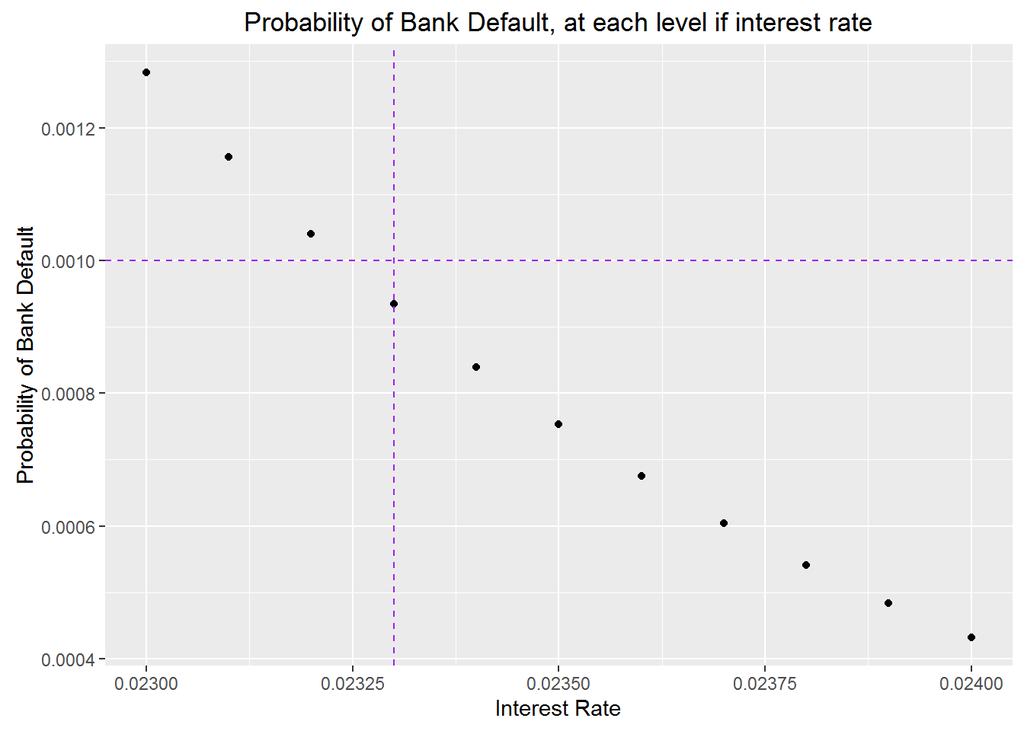

```r
# Look closer the interval contains 2.3%
filter(dat,rate>=0.023 & rate<=0.024)%>% ggplot(aes(x=rate,y=p))+geom_point()+xlab("Interest Rate")+ylab("Probability of Bank Default")+ggtitle("Probability of Bank Default, at each level if interest rate") +geom_vline(xintercept=min(dat$rate[dat$p<=0.001]) ,col='purple',linetype="dashed")+geom_hline(yintercept=0.001 ,col='purple',linetype="dashed")
```

```r
# Solution 2: Corroborate your answer with a Monte Carlo simulation
set.seed(02138)
nIter <-1000000
loss <- -120000
gain <-180000*better_rate
# probability of your bank loses money
mean(replicate(nIter,sum(sample(c(gain,loss),size=1000,replace=TRUE,prob=c(0.98,0.02)))<0))
```

```
## [1] 0.00239
```

```r
# Expected profit for 1,000 loans per year with this interest rate
1000*(-2400 + 176400*better_rate)
```

```
## [1] 1698947
```

Monte Carlo Simulation gives a slightly higher probability which is 0.00239.

## Problem 2F

Note that the Monte Carlo simulation gave a slightly higher probability than 0.001. What is a possible reason for this? Hint: See if the disparity is smaller for larger values of $p$. Also check for probabilities larger than 0.001. Recall we made an assumption when we calculated the interest rate.

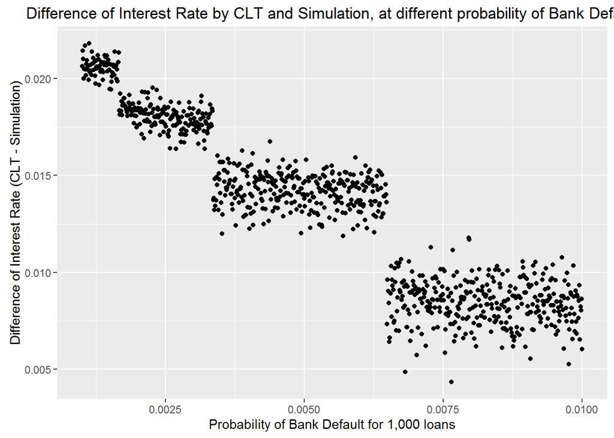

```r
##your code here

# Compare probability of bank default derived analytically and by Monte Carlo Simulation
set.seed(02138)

# initialize number of simulations
nIter <-10000
# prob of ban default
p <- seq(0.001,0.01,0.00001)
Normal_rate <- rep(NA,length(p))
MC_rate <- rep(NA,length(p))
diff <- rep(NA,length(p))

for(i in 1:length(p)){
  # CLT :
  fun <-function(x){
      ave <- 180000*x*0.98-120000*0.02
      std <- abs(180000*x+120000)*sqrt(0.98*0.02)/sqrt(1000)
      qnorm(p[i], mean=ave, sd=std )
  }
  Normal_rate[i] <- nleqslv(0,fun,jacobian=TRUE,control=list(btol=.01))$x
  # Simulation :
  loss <- -120000
  gain <-180000*Normal_rate[i]
  MC_rate[i]<-mean(replicate(nIter,sum(sample(c(gain,loss),size=1000,replace=TRUE,prob=c(0.98,0.02)))<0))

  # difference :
  diff[i] <-Normal_rate[i]-MC_rate[i]
}

dat <- data.frame(p,Normal_rate,MC_rate,diff)

dat%>%ggplot(aes(x=p,y=diff))+geom_point()+xlab("Probability of Bank Default for 1,000 loans") + ylab("Difference of Interest Rate (CLT - Simulation)")+ggtitle("Difference of Interest Rate by CLT and Simulation, at different probability of Bank Default")
```

Your answer here.

One possible reason is that, when we derive the distribution of bank default, we use the Central Limit Theorem to approximate it as Normally distributed. The central limit theorem works better and better when number of random draws gets larger and larger, so it could be that the distribution of the average of 1000 random draws has heavier tail than normal distribution. The normality assumption when we calculated the interest rate is the key assumption we could analytically solve the problem, and also the reason the result is a little bit deviate from what Monte Carlo Simulation suggests, which has no such distributional assumption.

## Problem 3

We were able to set an interest rate of about 2% that guaranteed a very low probability of having a loss. Furthermore, the expected average was over $1 million. Now other financial companies noticed the success of our business. They also noted that if we increase the number of loans we give, our profits increase. However, the pool of reliable borrowers was limited. So these other companies decided to give loans to less reliable borrowers but at a higher rate.

## Problem 3A

The pool of borrowers they found had a much higher default rate, estimated to be $p=0.05$. What interest rate would give these companies the same expected profit as your bank (Answer to 2E)?

$E= (-120000)(default rate)+ (180000)(interest rate)(1-default rate)$

```r
##your code here

your_profit <- 0.02*(-120000) + 180000*0.98*better_rate
fun <-function(x){0.05*(-120000)+180000*0.95*x-your_profit}
# What interest rate would give these companies the same expected profit as your bank (Answer to 2E)?
high_rate<-uniroot(fun,c(0,1))$root
high_rate
```

```
## [1] 0.04502308
```

## Problem 3B

At the interest rate calculated in 3A what is the probability of negative profits? Use both the normal approximation and then confirm with a Monte Carlo simulation.

```r
##your code here

# Solution 1: Normal Approximation
ave <- (-120000)*0.05 + 180000*0.95*high_rate
std <-abs(180000*high_rate+120000)*sqrt(0.05*0.95)/sqrt(1000)
# probability of negative profits?
pnorm(0, mean=ave, sd=std)
```

```
## [1] 0.0271593
```

```r
# Solution 2: Corroborate your answer with a Monte Carlo simulation
set.seed(02138)
nIter <-1000000
loss <- -120000
gain <-180000*high_rate
# probability of your bank loses money
mean(replicate(nIter,sum(sample(c(gain,loss),size=1000,replace=TRUE,prob=c(0.98,0.05)))<0))
```

```
## [1] 0.016557
```

Normal approximation and Monte Carlo Simulation give a slightly different probability: 0.0271593 vs 0.016557.

## Problem 3C

Note that the probability is much higher now. This is because the standard deviation grew. The companies giving out the loans did not want to raise interest rates much more since it would drive away clients. Instead they used a statistical approach. They increased $N$. How large does $N$ need to be for this probability to be 0.001? Use the central limit approximation and then confirm with a Monte Carlo simulation.

Your answer here.

By central limit theorem, the average of N independent random variable is approximately normally distributed, with mean: $E=(-120000)(0.05) + (180000)(1-0.05)(Interest Rate)$ and standard deviation: $SD=\frac{\mid (180000)(Interest Rate)-(-120000) \mid \sqrt{0.05(1-0.05)}}{sqrt(N)}$ .

```r
###your code here

# Central Limit Theorem: Normal approximation
library(nleqslv)

fun <-function(x){
  ave <- (-120000)*0.05 + 180000*0.95*high_rate
  std <-abs(180000*high_rate+120000)*sqrt(0.05*0.95)/sqrt(x)
  pnorm(0, mean=ave, sd=std)-0.001
}

#How large does $N$ need to be for this probability to be 0.001?
N<-nleqslv(1000,fun, jacobian=TRUE,control=list(btol=.01))$x
N
```

```
## [1] 2578.947
```

```r
# Monte Carlo Simulation
set.seed(02138)
# initialize number of simulations
nIter <-1000000
loss <- -120000
gain <-180000*high_rate
# probability of your bank loses money, in contrast to what CLT gave 0.001
mean(replicate(nIter,sum(sample(c(gain,loss),size=N,replace=TRUE,prob=c(0.98,0.05)))<0))
```

```
## [1] 0.000338
```

Monte Carlo Simulation gives lower bank default rate for the same number of loans.

So by doubling the number of loans we were able to reduce our risk! Now, for this to work, all the assumptions in our model need to be approximately correct, including the assumption that the probability of default was **independent**. This turned out to be false and the main reason for the under estimation of risk.

## Problem 3D

Define the following matrix of outcomes for two borrowers using our previous box model:

```r
loan <- 180000
loss_per_foreclosure <- 120000
p2 <- 0.05
interest_rate2 <- 0.05
B <- 10^5
outcomes1 <- replicate(B,{
  sample( c(-loss_per_foreclosure, interest_rate2*loan ), 2, replace=TRUE, prob=c(p2, 1-p2))
})
```

We can confirm independence by computing the probability of default for the second conditioned on the first defaulting:

```r
sum( outcomes1[1,] < 0 & outcomes1[2,]<0)/sum(outcomes1[1,]<0)
```

```
## [1] 0.04965545
```

This quantity is about the same as the probability of default $0.05$.

Now we create a new model. Before generating each set of defaults, we assume that a random event occurred that makes all default probabilities go up or go down by 4 points. We could see how this would happen if, for example, demand for houses decreases and all house prices drop.

```r
B <- 10^5
outcomes2 <- replicate(B,{
  add <- sample( c(-0.04,0.04), 1)
  sample( c(-loss_per_foreclosure, interest_rate2*loan ), 2, replace=TRUE, prob=c(p2+add, 1-(p2+add)))
})
```

Note that the outcomes are no longer independent as demonstrated by this result not being equal to 0.05

```r
sum( outcomes2[1,] < 0 & outcomes2[2,]<0)/sum(outcomes2[1,]<0)
```

```
## [1] 0.08225966
```

Generate a simulation with correlated outcomes such as those above. This time use the interest rate calculated in 3A. What is the expected earnings under this model compared to the previous? What is the probability of losing $1 million compared to the previous? What is the probability of losing $10 million compared to the previous?

```r
###your code here
set.seed(02138)

loan <- 180000
loss_per_foreclosure <- 120000
p2 <- 0.05
B <- 10^5

# simulate from independence model
outcomes1 <- replicate(B,
                       {sample( c(-loss_per_foreclosure, high_rate*loan ), 1000, replace=TRUE, prob=c(p2, 1-p2))})

# simulate from correlated model
outcomes2 <- replicate(B,
                       {
                        add <- sample( c(-0.04,0.04), 1)
                        sample( c(-loss_per_foreclosure, high_rate*loan ), 1000, replace=TRUE, prob=c(p2+add, 1-(p2+add)))
                        })

# What is the expected earnings under this model compared to the previous?
## correlated :
mean(apply(as.matrix(outcomes2),2,sum))
```

```
## [1] 1712072
```

```r
## previous independent:
mean(apply(as.matrix(outcomes1),2,sum))
```

```
## [1] 1702639
```

```r
# What is the probability of losing $1 million compared to the previous?
## correlated :
mean(as.numeric(apply(as.matrix(outcomes2),2,sum)<=-1000000))
```

```
## [1] 0.49033
```

```r
## previous independent:
mean(as.numeric(apply(as.matrix(outcomes1),2,sum)<=-1000000))
```

```
## [1] 0.00164
```

```r
# What is the probability of losing $10 million compared to the previous?
## correlated :
mean(as.numeric(apply(as.matrix(outcomes2),2,sum)<=-10000000))
```

```
## [1] 0
```

```r
## previous independent:
mean(as.numeric(apply(as.matrix(outcomes1),2,sum)<=-10000000))
```

```
## [1] 0
```

## Problem 4

Read [this wikipedia page](https://en.wikipedia.org/wiki/Financial_crisis_of_2007%E2%80%9308) about the financial crisis. Write a paragraph describing how what you learned in this homework can help explain the conditions that led to the crisis.

Your answer here.

Because incentives of lending and housing purchase, more money was in the housing market, the price of houses exceeded the value, so the real estate bubble incurred. Hereafter, loans of various types (e.g. mortgage) were easy to obtain by high risk population, and consumers overall assumed an unprecedented debt load.As part of the housing and credit booms, the number of financial agreements called mortgage-backed securities (MBS) and collateralized debt obligations (CDO), which derived their value from mortgage payments and housing prices, greeatly increased. Such financial innovation enableed institutions and investors around the world to invest in the U.S. hosing market.Housing bubble won’t last long, as soon as it fell, the falling prices reulsted in homes worth less than the mortgae loan, providing a financial incentive to enter foreclosure. Defaults and losses on housing and other loans increased significantly as the crisis expanded from the housing market to other parts of the economy.